# Weather events and their impacts in the USA

Mathias Barat

21/09/2020

# 1 - Synopsis

The present study is adressing several questions linked to the impacts dealt by weather events in the contemporary USA. We will focus mainly on the following points:

- Harmfulness of the events toward the population health
- Economic impacts of the events

The study is based on the NOAA Storm Database (URLs given hearafter) :

```r
url_storm_data <- "https://d396qusza40orc.cloudfront.net/repdata%2Fdata%2FStormData.csv.bz2"
url_storm_doc <- "https://d396qusza40orc.cloudfront.net/repdata%2Fpeer2_doc%2Fpd01016005curr.pdf"
url_storm_faq <- "https://d396qusza40orc.cloudfront.net/repdata%2Fpeer2_doc%2FNCDC%20Storm%20Events-FAQ%20Page.pdf"
```

The present study will answer to the following points:

- Across the United States, which types of events (as indicated in the EVTYPE variable) are most harmful with respect to population health?
- Across the United States, which types of events have the greatest economic consequences?

# 2 - DATA-PROCESSING

### PREPARATION

```r
library(ggplot2)
library(plyr)
library(dplyr)
```

### DATA LOADING

```r
if (!dir.exists("data/")){dir.create("data/")}
if (!file.exists("data/storm_data.csv")){
  download.file(url_storm_data, destfile = "data/storm_data.csv")
  download.file(url_storm_doc, destfile = "data/storm_doc.pdf")
  download.file(url_storm_faq, destfile = "data/storm_faq.pdf")
}

storm_data <- read.csv("data/storm_data.csv")
```

### DATA STRUCTURE

Here is some information about the RAW dataset :

```r
dim(storm_data)
```

```
## [1] 902297     37
```

There is 902297 observations for 37 variables.

```r
head(storm_data)
```

```
##   STATE__           BGN_DATE BGN_TIME TIME_ZONE COUNTY COUNTYNAME STATE  EVTYPE
## 1       1  4/18/1950 0:00:00     0130       CST     97     MOBILE    AL TORNADO
## 2       1  4/18/1950 0:00:00     0145       CST      3    BALDWIN    AL TORNADO
## 3       1  2/20/1951 0:00:00     1600       CST     57    FAYETTE    AL TORNADO
## 4       1   6/8/1951 0:00:00     0900       CST     89    MADISON    AL TORNADO
## 5       1 11/15/1951 0:00:00     1500       CST     43    CULLMAN    AL TORNADO
## 6       1 11/15/1951 0:00:00     2000       CST     77 LAUDERDALE    AL TORNADO
##   BGN_RANGE BGN_AZI BGN_LOCATI END_DATE END_TIME COUNTY_END COUNTYENDN
## 1         0                                               0         NA
## 2         0                                               0         NA
## 3         0                                               0         NA
## 4         0                                               0         NA
## 5         0                                               0         NA
## 6         0                                               0         NA
##   END_RANGE END_AZI END_LOCATI LENGTH WIDTH F MAG FATALITIES INJURIES PROPDMG
```

[output cut: 20 more lines]

```r
str(storm_data)
```

```
## 'data.frame':    902297 obs. of  37 variables:
##  $ STATE__   : num  1 1 1 1 1 1 1 1 1 1 ...
##  $ BGN_DATE  : chr  "4/18/1950 0:00:00" "4/18/1950 0:00:00" "2/20/1951 0:00:00" "6/8/1951 0:00:00" ...
##  $ BGN_TIME  : chr  "0130" "0145" "1600" "0900" ...
##  $ TIME_ZONE : chr  "CST" "CST" "CST" "CST" ...
##  $ COUNTY    : num  97 3 57 89 43 77 9 123 125 57 ...
##  $ COUNTYNAME: chr  "MOBILE" "BALDWIN" "FAYETTE" "MADISON" ...
##  $ STATE     : chr  "AL" "AL" "AL" "AL" ...
##  $ EVTYPE    : chr  "TORNADO" "TORNADO" "TORNADO" "TORNADO" ...
##  $ BGN_RANGE : num  0 0 0 0 0 0 0 0 0 0 ...
##  $ BGN_AZI   : chr  "" "" "" "" ...
##  $ BGN_LOCATI: chr  "" "" "" "" ...
##  $ END_DATE  : chr  "" "" "" "" ...
##  $ END_TIME  : chr  "" "" "" "" ...
##  $ COUNTY_END: num  0 0 0 0 0 0 0 0 0 0 ...
```

[output cut: 23 more lines]

### Extract Data Variables of Interests

We can see that a lot of variables are not useful for our study (empty or not relevant). I am capitalizing hereafter the variables I will keep for my analysis:

### Health Variables:

- FATALITIES
- INJURIES

### Economics Variables:

- PROPDMG
- PROPDMGEXP
- CROPDMG
- CROPDMGEXP

### Study Variables:

- STATE
- EVTYPE

```r
Cols_to_keep <- c("STATE", "EVTYPE","FATALITIES", "INJURIES", "PROPDMG","PROPDMGEXP", "CROPDMG", "CROPDMGEXP")
storm_data_wip <- storm_data[ ,Cols_to_keep]
```

### Check NA

```r
sum(is.na(storm_data_wip))
```

```
## [1] 0
```

There is no NA in the filtered dataset

### Clean EVTYPE

In order to be more accurate, we will regroup the EVTYPE has too much similar observations which can be packed

Creation of storm_data_wip$EVENT

```r
storm_data_wip$EVENT <- "OTHER"
storm_data_wip$EVENT[grep("HAIL", storm_data_wip$EVTYPE, ignore.case = TRUE)] <- "HAIL"
storm_data_wip$EVENT[grep("WIND", storm_data_wip$EVTYPE, ignore.case = TRUE)] <- "WIND"
storm_data_wip$EVENT[grep("TORNADO", storm_data_wip$EVTYPE, ignore.case = TRUE)] <- "TORNADO"
storm_data_wip$EVENT[grep("FLOOD", storm_data_wip$EVTYPE, ignore.case = TRUE)] <- "FLOOD"
storm_data_wip$EVENT[grep("LIGHTNING", storm_data_wip$EVTYPE, ignore.case = TRUE)] <- "LIGHTNING"
storm_data_wip$EVENT[grep("SNOW", storm_data_wip$EVTYPE, ignore.case = TRUE)] <- "SNOW"
storm_data_wip$EVENT[grep("RAIN", storm_data_wip$EVTYPE, ignore.case = TRUE)] <- "RAIN"
storm_data_wip$EVENT[grep("STORM", storm_data_wip$EVTYPE, ignore.case = TRUE)] <- "STORM"
storm_data_wip$EVENT[grep("TSTM", storm_data_wip$EVTYPE, ignore.case = TRUE)] <- "THUNDERSTORM"
storm_data_wip$EVENT[grep("THUNDERSTORM", storm_data_wip$EVTYPE, ignore.case = TRUE)] <- "THUNDERSTORM"
storm_data_wip$EVENT[grep("FIRE", storm_data_wip$EVTYPE, ignore.case = TRUE)] <- "FIRE"
storm_data_wip$EVENT[grep("FOG", storm_data_wip$EVTYPE, ignore.case = TRUE)] <- "FOG"
storm_data_wip$EVENT[grep("BLIZZARD", storm_data_wip$EVTYPE, ignore.case = TRUE)] <- "BLIZZARD"
storm_data_wip$EVENT[grep("HEAT", storm_data_wip$EVTYPE, ignore.case = TRUE)] <- "HEAT"
storm_data_wip$EVENT[grep("FUNNEL CLOUD", storm_data_wip$EVTYPE, ignore.case = TRUE)] <- "FUNNEL CLOUD"
storm_data_wip$EVENT[grep("COLD", storm_data_wip$EVTYPE, ignore.case = TRUE)] <- "COLD"
storm_data_wip$EVENT[grep("WATERSPOUT", storm_data_wip$EVTYPE, ignore.case = TRUE)] <- "WATERSPOUT"
```

### Dollar conversion

As the amount of damages are expressed with expression such as K, M, B in the …EXP columns. We need to create first columns with actual dollars:

```r
storm_data_wip$PROPDMGEXP <- as.character(storm_data_wip$PROPDMGEXP)
storm_data_wip$PROPDMGEXP[is.na(storm_data_wip$PROPDMGEXP)] <- 0
storm_data_wip$PROPDMGEXP[!grepl("K|M|B", storm_data_wip$PROPDMGEXP, ignore.case = TRUE)] <- 0
storm_data_wip$PROPDMGEXP[grep("K", storm_data_wip$PROPDMGEXP, ignore.case = TRUE)] <- "3"
storm_data_wip$PROPDMGEXP[grep("M", storm_data_wip$PROPDMGEXP, ignore.case = TRUE)] <- "6"
storm_data_wip$PROPDMGEXP[grep("B", storm_data_wip$PROPDMGEXP, ignore.case = TRUE)] <- "9"
storm_data_wip$PROPDMGEXP <- as.numeric(as.character(storm_data_wip$PROPDMGEXP))
storm_data_wip$PROPDMG <- as.numeric(as.character(storm_data_wip$PROPDMG))
storm_data_wip$PROPDMG.DOLLAR <- storm_data_wip$PROPDMG * 10^storm_data_wip$PROPDMGEXP

storm_data_wip$CROPDMGEXP <- as.character(storm_data_wip$CROPDMGEXP)
storm_data_wip$CROPDMGEXP[is.na(storm_data_wip$CROPDMGEXP)] <- 0 # NA's considered as dollars
storm_data_wip$CROPDMGEXP[!grepl("K|M|B", storm_data_wip$CROPDMGEXP, ignore.case = TRUE)] <- 0
storm_data_wip$CROPDMGEXP[grep("K", storm_data_wip$CROPDMGEXP, ignore.case = TRUE)] <- "3"
storm_data_wip$CROPDMGEXP[grep("M", storm_data_wip$CROPDMGEXP, ignore.case = TRUE)] <- "6"
storm_data_wip$CROPDMGEXP[grep("B", storm_data_wip$CROPDMGEXP, ignore.case = TRUE)] <- "9"
storm_data_wip$CROPDMGEXP <- as.numeric(as.character(storm_data_wip$CROPDMGEXP))
storm_data_wip$CROPDMG.DOLLAR <- storm_data_wip$CROPDMG * 10^storm_data_wip$CROPDMGEXP
```

### Health Data Preparation

```r
Mycolnames <- c("EVENT", "TOTAL", "TYPE")
most_dangerous_events.injuries <- aggregate( INJURIES ~ EVENT , storm_data_wip, sum)
most_dangerous_events.injuries$TYPE <- "INJURIES"
colnames(most_dangerous_events.injuries) <- Mycolnames

most_dangerous_events.fatalities <- aggregate( FATALITIES ~ EVENT , storm_data_wip, sum)
most_dangerous_events.fatalities$TYPE <- "FATALITIES"
colnames(most_dangerous_events.fatalities)  <- Mycolnames

most_dangerous_events <- rbind(most_dangerous_events.fatalities, most_dangerous_events.injuries)
```

### Damage Data Preparation

```r
damages.prop <- aggregate( PROPDMG.DOLLAR ~ EVENT , storm_data_wip, sum)
damages.prop$TYPE <- "PROP"
colnames(damages.prop) <- Mycolnames

damages.crop <- aggregate( CROPDMG.DOLLAR ~ EVENT , storm_data_wip, sum)
damages.crop$TYPE <- "CROP"
colnames(damages.crop)  <- Mycolnames

damages <- rbind(damages.prop, damages.crop)
```

# 3 - RESULTS

### EVENTS ANALYSIS

```r
frequent_events <- as.data.frame(sort(table(storm_data_wip$EVENT), decreasing=TRUE)[1:30])
```

#### Global numbers for health:

Total amount of fatalities in the dataset:

```r
sum(storm_data_wip$FATALITIES)
```

```
## [1] 15145
```

Total amount of injuries in the dataset:

```r
sum(storm_data_wip$INJURIES)
```

```
## [1] 140528
```

## GEOGRAPHICAL ANALYSIS

```r
most_impacted_states.events <- as.data.frame(with(storm_data_wip, table(EVENT,STATE)))
most_impacted_states.events <- most_impacted_states.events[order(most_impacted_states.events$Freq, decreasing = TRUE),]
```

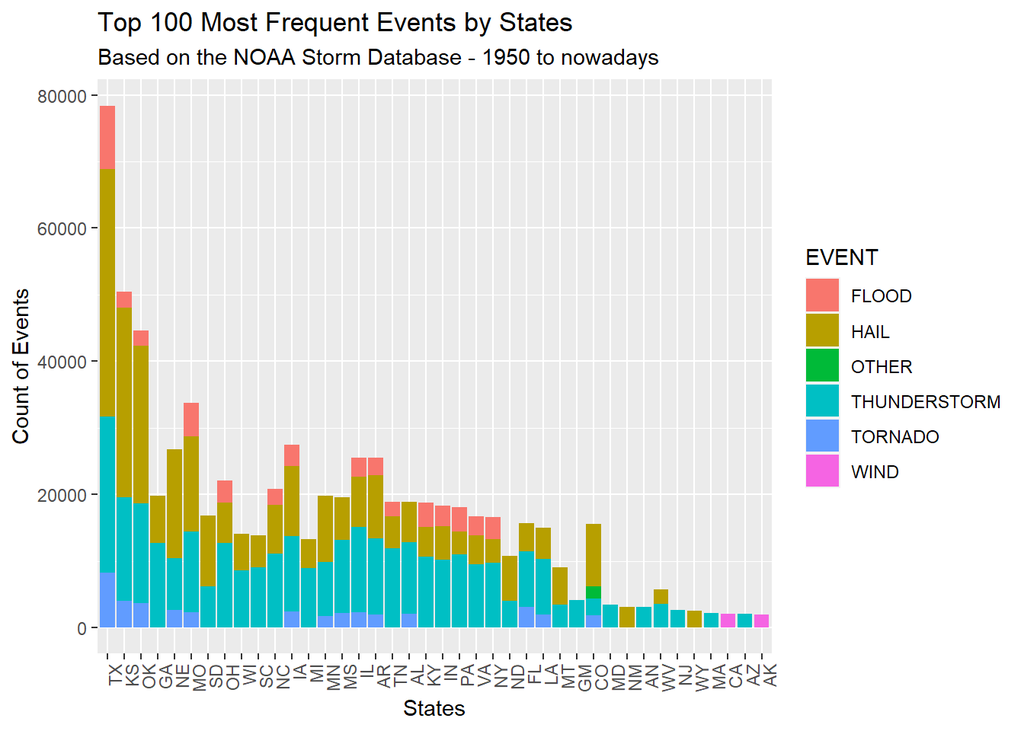

```r
ggplot(most_impacted_states.events[1:100,] , aes(reorder(STATE, -Freq) ,Freq, fill = EVENT)) +
  geom_bar(stat='identity') +
  ylab("Count of Events")+
  xlab("States")+
  theme(axis.text.x=element_text(angle=90,hjust = 1))+
  ggtitle("Top 100 Most Frequent Events by States", subtitle = "Based on the NOAA Storm Database - 1950 to nowadays")
```

## HARMFULNESS ANALYSIS

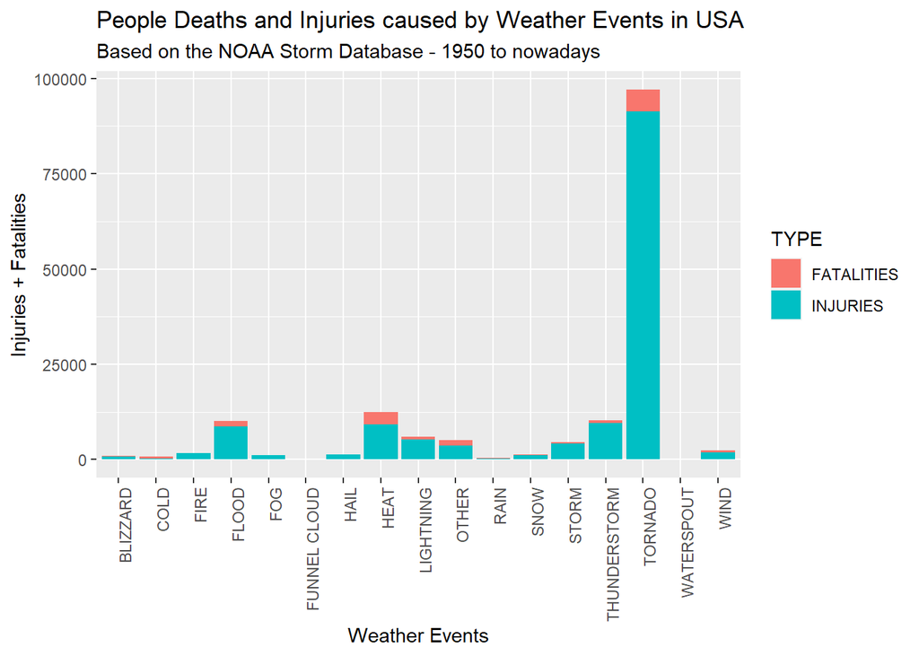

```r
ggplot(most_dangerous_events , aes(EVENT, TOTAL , fill = TYPE)) +
  geom_bar(stat='identity') +
  ylab("Injuries + Fatalities")+
  xlab("Weather Events")+
  theme(axis.text.x=element_text(angle=90,hjust = 1))+
  ggtitle("People Deaths and Injuries caused by Weather Events in USA", subtitle = "Based on the NOAA Storm Database - 1950 to nowadays")
```

### Sum-up

Tornados are far more the most dangerous weather events USA is dealing with. They are responsible of more than 90000 injuries and more than 5000 fatalities.

Heat has a high amount of fatalities as it has killed more than 3000 people since 1950. Floods are closing the top killers with around 1500 deaths.

## DAMAGE ANALYSIS

[figure not shown]

```r
ggplot(damages , aes(EVENT, TOTAL , fill = TYPE)) +
  geom_bar(stat='identity') +
  ylab("Total Damage in Dollars")+
  xlab("Weather Events")+
  theme(axis.text.x=element_text(angle=90,hjust = 1))+
  ggtitle("People Deaths and Injuries caused by Weather Events in USA", subtitle = "Based on the NOAA Storm Database - 1950 to nowadays")
```

### Sum-up

Floods caused more than 170 Billion dollars of damages since 1950.